# Verbos de una sola tabla

Sesión 1

Luis F. Gomez L.

luis.gomezl@unimilitar.edu.co

Facultad de Estudios a Distancia

2026-09-24

# Preliminaries

- Verificar:
  - ¿La carpeta `data` fue creada?
  - ¿`2021-2024_saber-pro-genericas_faedis.rds` se encuentra dentro de la carpeta `data`?
- Generar carpetas:
  - `010_verbos-una-sola-tabla-en-r`
    - Crear archivo `001_manipular-datos-una-sola-tabla.R`
- Descargar datos: `2021_2024-saber_pro-genericas.csv.xz`
  - Agregar en `data`

# Gramática de manipulación de datos en `dplyr`

El paquete `dplyr`, incluido en el `tidyverse`, permite manipular datos a partir de un conjunto de datos en 2 niveles:

1. Dentro de una sola tabla de datos
2. Entre diferentes tablas de datos

En esta sesión abarcaremos el nivel 1. Luego en la próxima sesión abarcaremos el nivel 2.

En el paquete `dplyr`, para mantener la consistencia de las funciones que lo componen, siempre se cumple que cada uno de los verbos obedece a los siguientes aspectos (Wickham 2023, cap. 3):

1. El primer argumento es una tibble (o en su defecto un objeto de R similar).
2. Los argumentos subsiguientes especifican las columnas, filas o expresiones que operarán sobre las filas o columnas.
3. El resultado[^1] de una función en `dplyr` es siempre una nueva tibble (o en su defecto un objeto de R similar).

## Verbos

Los verbos para manipular datos en una sola tabla se encuentran organizados en 3 categorías teniendo en cuenta el elemento que se desea manipular:

1. Verbos para filas
2. Verbos para columnas
3. Verbos para colapsar, agrupar o desagrupar filas

## Verbos para filas

En esta categoría se incluyen las funciones:

- `filter()`
- `slice()`
- `arrange()`

## `filter()`

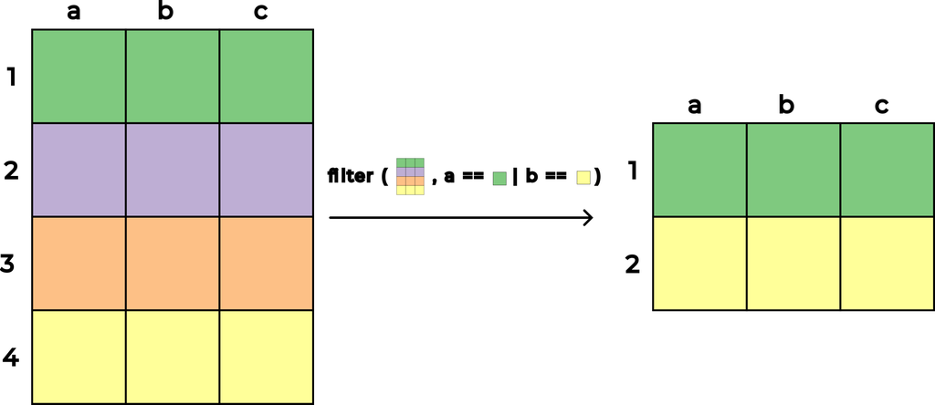

Figura 1: Representación gráfica de la función `filter()`

## `filter()`

```r
# Cargar paquetes ----
library(tidyverse)

# Importar datos ----
saber_pro_genericas_faedis_2021_2024 <- read_rds(
  file = "data/2021-2024_saber-pro-genericas_faedis.rds"
)

# Filtrar ---
filter(
  saber_pro_genericas_faedis_2021_2024,
  ano == 2022 & estu_genero == "M"
)
```

```
# A tibble: 194 × 21
     ano estu_consecutivo estu_genero estu_semestrecursa fami_estratovivienda
   <int> <chr>            <fct>       <ord>              <ord>
 1  2022 EK202220120492   M           09                 Estrato 3
 2  2022 EK202220159443   M           08                 Estrato 2
 3  2022 EK202220121639   M           09                 Estrato 3
 4  2022 EK202220120505   M           09                 Estrato 4
 5  2022 EK202220120480   M           08                 Estrato 4
 6  2022 EK202220128207   M           08                 Estrato 3
 7  2022 EK202220121516   M           09                 Estrato 3
 8  2022 EK202220120491   M           08                 Estrato 2
 9  2022 EK202220120507   M           10                 Estrato 4
10  2022 EK202220120496   M           08                 Estrato 2
# ℹ 184 more rows
# ℹ 16 more variables: fami_educacionmadre <ord>, fami_educacionpadre <ord>,
#   estu_exterior <chr>, estu_cod_depto_presentacion <chr>,
#   estu_depto_presentacion <chr>, estu_cod_mcpio_presentacion <chr>,
#   estu_mcpio_presentacion <chr>, estu_snies_prgmacademico <int>,
#   estu_prgm_academico <chr>, mod_competen_ciudada_punt <dbl>,
#   mod_comuni_escrita_punt <dbl>, mod_ingles_punt <dbl>, …
```

## `slice()`

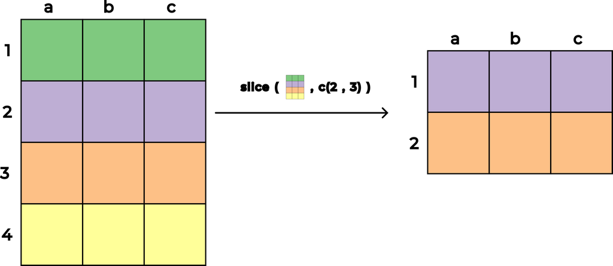

Figura 2: Representación gráfica de la función `slice()`

## `slice()`

```r
# Seleccionar filas por posición ----
slice(
  saber_pro_genericas_faedis_2021_2024,
  c(1, 3, 5)
)
```

```
# A tibble: 3 × 21
    ano estu_consecutivo estu_genero estu_semestrecursa fami_estratovivienda
  <int> <chr>            <fct>       <ord>              <ord>
1  2021 EK202120262469   M           09                 Estrato 3
2  2021 EK202120116868   M           09                 Estrato 5
3  2021 EK202120116814   F           09                 Estrato 2
# ℹ 16 more variables: fami_educacionmadre <ord>, fami_educacionpadre <ord>,
#   estu_exterior <chr>, estu_cod_depto_presentacion <chr>,
#   estu_depto_presentacion <chr>, estu_cod_mcpio_presentacion <chr>,
#   estu_mcpio_presentacion <chr>, estu_snies_prgmacademico <int>,
#   estu_prgm_academico <chr>, mod_competen_ciudada_punt <dbl>,
#   mod_comuni_escrita_punt <dbl>, mod_ingles_punt <dbl>,
#   mod_ingles_desem <ord>, mod_lectura_critica_punt <dbl>, …
```

## `slice()`

La función `slice()` tiene asociado un conjunto de funciones auxiliares de la forma `slice_*` que pueden ser útiles para seleccionar determinadas filas:

1. `slice_head()` y `slice_tail()` permiten seleccionar las primeras o últimas filas.
2. `slice_sample()` permite seleccionar filas de manera aleatoria.
3. `slice_min()` y `slice_max()` permiten seleccionar aquellas filas que contienen los valores más pequeños o más grandes de una determinada variable.

## `arrange()`

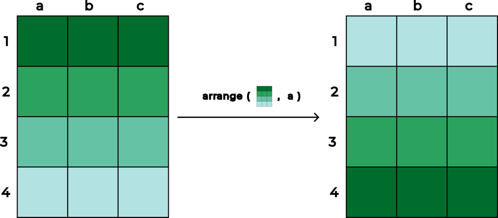

Figura 3: Representación gráfica de la función `arrange()`

## `arrange()`

- Por defecto, `arrange()` ordena los datos de forma ascendente.
- En caso de necesitar un ordenamiento descendente, se debe aplicar la función auxiliar `desc()` sobre la variable que se desee organizar bajo ese criterio.

## `arrange()`

```r
arrange(
  saber_pro_genericas_faedis_2021_2024,
  desc(ano),
  estu_semestrecursa
)
```

```
# A tibble: 1,239 × 21
     ano estu_consecutivo estu_genero estu_semestrecursa fami_estratovivienda
   <int> <chr>            <fct>       <ord>              <ord>
 1  2024 EK202430030817   F           06                 Estrato 5
 2  2024 EK202430030783   F           06                 Estrato 3
 3  2024 EK202410086302   F           07                 Estrato 4
 4  2024 EK202410000136   F           07                 Estrato 3
 5  2024 EK202410000145   M           07                 Estrato 3
 6  2024 EK202410129804   F           07                 Estrato 2
 7  2024 EK202410067203   M           07                 Estrato 3
 8  2024 EK202410067226   M           07                 Estrato 2
 9  2024 EK202410129912   M           07                 Estrato 3
10  2024 EK202410129981   M           07                 Estrato 2
# ℹ 1,229 more rows
# ℹ 16 more variables: fami_educacionmadre <ord>, fami_educacionpadre <ord>,
#   estu_exterior <chr>, estu_cod_depto_presentacion <chr>,
#   estu_depto_presentacion <chr>, estu_cod_mcpio_presentacion <chr>,
#   estu_mcpio_presentacion <chr>, estu_snies_prgmacademico <int>,
#   estu_prgm_academico <chr>, mod_competen_ciudada_punt <dbl>,
#   mod_comuni_escrita_punt <dbl>, mod_ingles_punt <dbl>, …
```

## Verbos para columnas

En esta categoría se incluyen las funciones:

- `select()`
- `rename()`
- `mutate()`
- `relocate()`

## `select()`

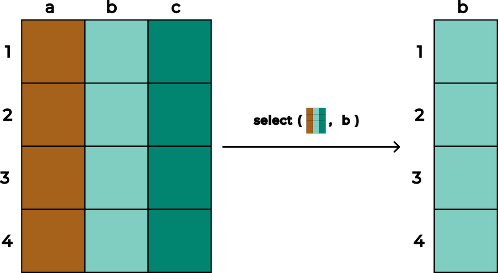

Figura 4: Representación gráfica de la función `select()`

## `select()`

```r
select(
  saber_pro_genericas_faedis_2021_2024,
  ano,
  estu_consecutivo,
  punt_global
)
```

```
# A tibble: 1,239 × 3
     ano estu_consecutivo punt_global
   <int> <chr>                  <dbl>
 1  2021 EK202120262469           139
 2  2021 EK202120116785           170
 3  2021 EK202120116868           128
 4  2021 EK202120116831           155
 5  2021 EK202120116814           166
 6  2021 EK202120117053           142
 7  2021 EK202120262258           151
 8  2021 EK202120262692           145
 9  2021 EK202120117033           132
10  2021 EK202120117014           146
# ℹ 1,229 more rows
```

## `rename()`

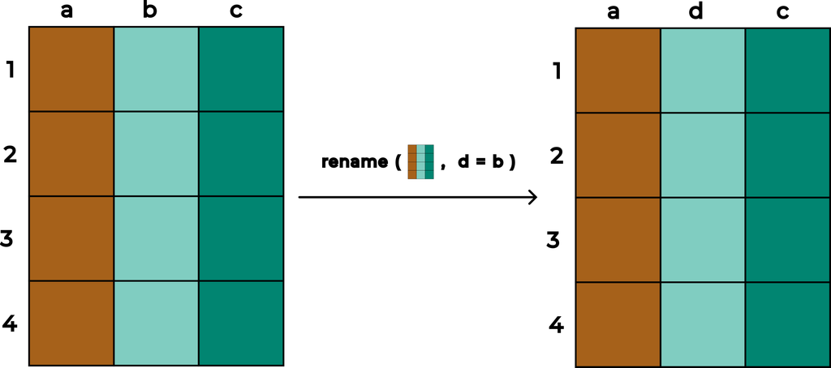

Figura 5: Representación gráfica de la función `rename()`

## `rename()`

```r
rename(
  saber_pro_genericas_faedis_2021_2024,
  id_saber_pro_estudiante = estu_consecutivo
)
```

```
# A tibble: 1,239 × 21
     ano id_saber_pro_estudiante estu_genero estu_semestrecursa
   <int> <chr>                   <fct>       <ord>
 1  2021 EK202120262469          M           09
 2  2021 EK202120116785          M           09
 3  2021 EK202120116868          M           09
 4  2021 EK202120116831          M           09
 5  2021 EK202120116814          F           09
 6  2021 EK202120117053          F           09
 7  2021 EK202120262258          F           08
 8  2021 EK202120262692          F           09
 9  2021 EK202120117033          F           08
10  2021 EK202120117014          F           08
# ℹ 1,229 more rows
# ℹ 17 more variables: fami_estratovivienda <ord>, fami_educacionmadre <ord>,
#   fami_educacionpadre <ord>, estu_exterior <chr>,
#   estu_cod_depto_presentacion <chr>, estu_depto_presentacion <chr>,
#   estu_cod_mcpio_presentacion <chr>, estu_mcpio_presentacion <chr>,
#   estu_snies_prgmacademico <int>, estu_prgm_academico <chr>,
#   mod_competen_ciudada_punt <dbl>, mod_comuni_escrita_punt <dbl>, …
```

## `mutate()`

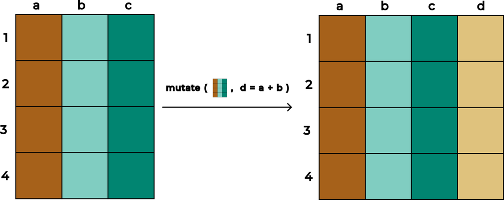

Figura 6: Representación gráfica de la función `mutate()`

## `mutate()`

```r
mutate(
  saber_pro_genericas_faedis_2021_2024,
  punt_global_norm = (punt_global - min(punt_global)) /
    (max(punt_global) - min(punt_global)),
  .keep = "used"
)
```

- Si $x$ es una variable numérica entonces su normalización en el intervalo $[0, 1]$ se puede definir como $x_{norm} = \frac{x- \min(x)}{\max(x) - \min(x)}$ donde $\min(x)$ es el valor mínimo de la variable $x$ y $\max(x)$ es el valor máximo de la variable $x$.

```
# A tibble: 1,239 × 2
   punt_global punt_global_norm
         <dbl>            <dbl>
 1         139            0.610
 2         170            0.746
 3         128            0.561
 4         155            0.680
 5         166            0.728
 6         142            0.623
 7         151            0.662
 8         145            0.636
 9         132            0.579
10         146            0.640
# ℹ 1,229 more rows
```

## `relocate()`

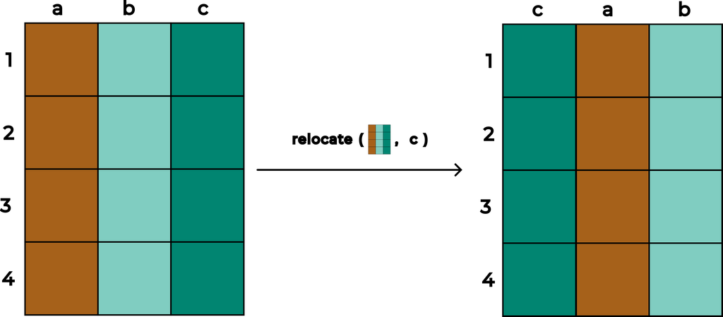

Figura 7: Representación gráfica de la función `relocate()`

## `relocate()`

```r
relocate(
  saber_pro_genericas_faedis_2021_2024,
  punt_global,
  .after = estu_consecutivo
)
```

```
# A tibble: 1,239 × 21
     ano estu_consecutivo punt_global estu_genero estu_semestrecursa
   <int> <chr>                  <dbl> <fct>       <ord>
 1  2021 EK202120262469           139 M           09
 2  2021 EK202120116785           170 M           09
 3  2021 EK202120116868           128 M           09
 4  2021 EK202120116831           155 M           09
 5  2021 EK202120116814           166 F           09
 6  2021 EK202120117053           142 F           09
 7  2021 EK202120262258           151 F           08
 8  2021 EK202120262692           145 F           09
 9  2021 EK202120117033           132 F           08
10  2021 EK202120117014           146 F           08
# ℹ 1,229 more rows
# ℹ 16 more variables: fami_estratovivienda <ord>, fami_educacionmadre <ord>,
#   fami_educacionpadre <ord>, estu_exterior <chr>,
#   estu_cod_depto_presentacion <chr>, estu_depto_presentacion <chr>,
#   estu_cod_mcpio_presentacion <chr>, estu_mcpio_presentacion <chr>,
#   estu_snies_prgmacademico <int>, estu_prgm_academico <chr>,
#   mod_competen_ciudada_punt <dbl>, mod_comuni_escrita_punt <dbl>, …
```

## Operador pipe (`|>`)

- Cuando se manipulan datos usualmente se requieren combinar múltiples verbos para contestar una determinada pregunta.
- El operador pipe (`|>`) permite realizar este proceso donde fue introducido en la versión `4.1.0` de R.

Tabla 1: Uso e interpretación del operador pipe (`|>`)

| Uso | Interpretación |
| --- | --- |
| $a \;\lvert>\; f(x)$ | $f(x = a)$ |
| $b \;\lvert>\; f(x, y)$ | $f(x = b, y)$ |
| $c \;\lvert>\; f(x) \;\lvert>\; g(y)$ | $g(y = f(x = c))$ |
| $d \;\lvert>\; f(x, y = \_)$ | $f(x, y = d)$ |

## Operador pipe (`|>`)

```r
saber_pro_genericas_faedis_2021_2024 |>
  select(
    ano,
    estu_consecutivo,
    estu_snies_prgmacademico,
    estu_prgm_academico,
    mod_competen_ciudada_punt,
    mod_comuni_escrita_punt,
    mod_ingles_punt,
    mod_lectura_critica_punt,
    mod_razona_cuantitat_punt
  ) |>
  filter(
    mod_competen_ciudada_punt == 0 |
      mod_comuni_escrita_punt == 0 |
      mod_ingles_punt == 0 |
      mod_lectura_critica_punt == 0 |
      mod_razona_cuantitat_punt == 0
  ) |>
  arrange(estu_prgm_academico) |>
  glimpse()
```

```
Rows: 85
Columns: 9
$ ano                       <int> 2021, 2021, 2022, 2022, 2022, 2022, 2022, 20…
$ estu_consecutivo          <chr> "EK202120264262", "EK202130321488", "EK20222…
$ estu_snies_prgmacademico  <int> 6527, 6527, 6527, 6527, 6527, 6527, 6527, 65…
$ estu_prgm_academico       <chr> "ADMINISTRACION DE EMPRESAS", "ADMINISTRACIO…
$ mod_competen_ciudada_punt <dbl> 77, 0, 0, 136, 122, 83, 155, 112, 0, 132, 10…
$ mod_comuni_escrita_punt   <dbl> 0, 128, 0, 0, 0, 0, 0, 173, 134, 0, 0, 0, 0,…
$ mod_ingles_punt           <dbl> 187, 0, 0, 164, 144, 146, 183, 0, 0, 142, 82…
$ mod_lectura_critica_punt  <dbl> 92, 64, 0, 143, 132, 123, 153, 181, 106, 124…
$ mod_razona_cuantitat_punt <dbl> 130, 0, 0, 107, 155, 146, 94, 167, 150, 151,…
```

## Ventajas uso del operador `|>`

- Estructurar el proceso de manipulación de datos de manera secuencial
  - De izquierda a derecha
  - Permite leer el código de arriba hacia abajo
- Minimiza la necesidad de crear variables intermedias o definiciones de funciones
- Facilitar agregar o eliminar pasos en cualquier parte de la secuencia

## Funciones anidadas vs `|>`

```r
glimpse(
  arrange(
    filter(
      select(
        saber_pro_genericas_faedis_2021_2024,
        ano,
        estu_consecutivo,
        estu_snies_prgmacademico,
        estu_prgm_academico,
        mod_competen_ciudada_punt,
        mod_comuni_escrita_punt,
        mod_ingles_punt,
        mod_lectura_critica_punt,
        mod_razona_cuantitat_punt
      ),
      mod_competen_ciudada_punt == 0 |
        mod_comuni_escrita_punt == 0 |
        mod_ingles_punt == 0 |
        mod_lectura_critica_punt == 0 |
        mod_razona_cuantitat_punt == 0
    ),
    estu_prgm_academico
  )
)
```

## Variables intermedias vs `|>`

```r
# Seleccionar columnas ----
datos_seleccionados <- select(
  saber_pro_genericas_faedis_2021_2024,
  ano,
  estu_consecutivo,
  estu_snies_prgmacademico,
  estu_prgm_academico,
  mod_competen_ciudada_punt,
  mod_comuni_escrita_punt,
  mod_ingles_punt,
  mod_lectura_critica_punt,
  mod_razona_cuantitat_punt
)

# Filtrar filas con ceros ----
datos_filtrados <- filter(
  datos_seleccionados,
  mod_competen_ciudada_punt == 0 |
    mod_comuni_escrita_punt == 0 |
    mod_ingles_punt == 0 |
    mod_lectura_critica_punt == 0 |
    mod_razona_cuantitat_punt == 0
)

# Ordenar por programa académico ---
datos_ordenados <- arrange(
  datos_filtrados,
  estu_prgm_academico
)

# "Vistazo" de datos ----
glimpse(datos_ordenados)
```

## Verbos para colapsar, agrupar y desagrupar filas

En esta categoría se incluyen las funciones:

- `group_by()`
- `summarise()`
- `ungroup()`

## `group_by()`

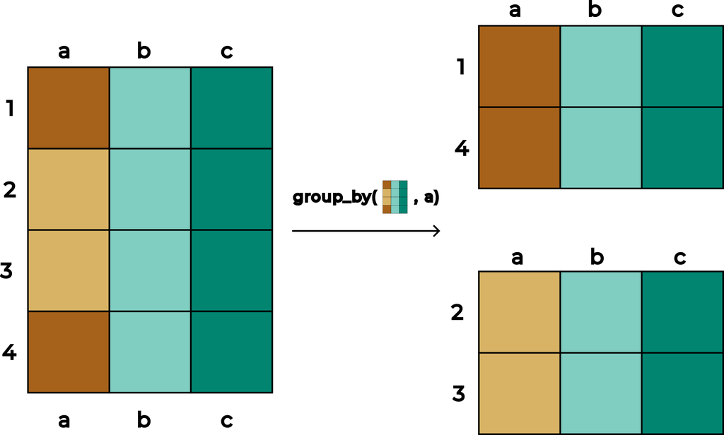

Figura 8: Representación gráfica de la función `group_by()`

## `group_by()`

```r
saber_pro_genericas_faedis_2021_2024 |>
  group_by(
    ano,
    estu_genero
  )
```

```
# A tibble: 1,239 × 21
# Groups:   ano, estu_genero [8]
     ano estu_consecutivo estu_genero estu_semestrecursa fami_estratovivienda
   <int> <chr>            <fct>       <ord>              <ord>
 1  2021 EK202120262469   M           09                 Estrato 3
 2  2021 EK202120116785   M           09                 Estrato 4
 3  2021 EK202120116868   M           09                 Estrato 5
 4  2021 EK202120116831   M           09                 Estrato 4
 5  2021 EK202120116814   F           09                 Estrato 2
 6  2021 EK202120117053   F           09                 Estrato 2
 7  2021 EK202120262258   F           08                 Estrato 3
 8  2021 EK202120262692   F           09                 Estrato 2
 9  2021 EK202120117033   F           08                 <NA>
10  2021 EK202120117014   F           08                 Estrato 3
# ℹ 1,229 more rows
# ℹ 16 more variables: fami_educacionmadre <ord>, fami_educacionpadre <ord>,
#   estu_exterior <chr>, estu_cod_depto_presentacion <chr>,
#   estu_depto_presentacion <chr>, estu_cod_mcpio_presentacion <chr>,
#   estu_mcpio_presentacion <chr>, estu_snies_prgmacademico <int>,
#   estu_prgm_academico <chr>, mod_competen_ciudada_punt <dbl>,
#   mod_comuni_escrita_punt <dbl>, mod_ingles_punt <dbl>, …
```

## `summarise()`

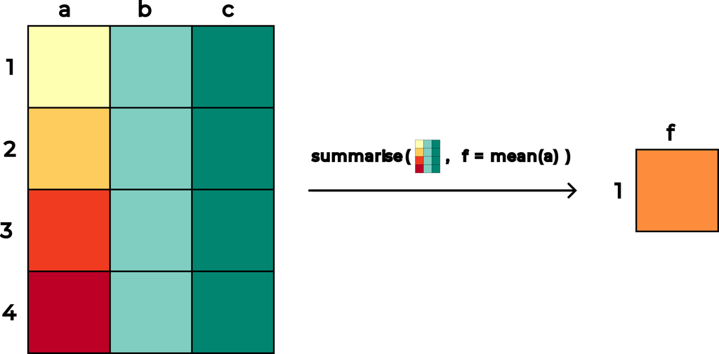

Figura 9: Representación gráfica de la función `summarise()`

## `summarise()`

```r
saber_pro_genericas_faedis_2021_2024 |>
  group_by(
    ano,
    estu_genero
  ) |>
  summarise(
    punt_global = mean(punt_global) |>
      round(digits = 0)
  )
```

```
# A tibble: 8 × 3
# Groups:   ano [4]
    ano estu_genero punt_global
  <int> <fct>             <dbl>
1  2021 F                   147
2  2021 M                   148
3  2022 F                   144
4  2022 M                   147
5  2023 F                   148
6  2023 M                   147
7  2024 F                   150
8  2024 M                   148
```

## `ungroup()`

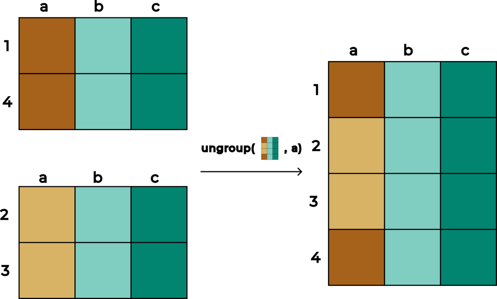

Figura 10: Representación gráfica de la función `ungroup()`

## `ungroup()`

```r
saber_pro_genericas_faedis_2021_2024 |>
  group_by(
    ano,
    estu_genero
  ) |>
  summarise(
    punt_global = mean(punt_global) |>
      round(digits = 0)
  ) |>
  ungroup()
```

```
# A tibble: 8 × 3
    ano estu_genero punt_global
  <int> <fct>             <dbl>
1  2021 F                   147
2  2021 M                   148
3  2022 F                   144
4  2022 M                   147
5  2023 F                   148
6  2023 M                   147
7  2024 F                   150
8  2024 M                   148
```

# Caso de estudio: obtención de datos de interés del Saber-Pro para FAEDIS

## Datos

```r
# Importar datos ----
saber_pro_genericas_2021_2024 <- read_csv(
  file = "data/2021_2024-saber_pro-genericas.csv.xz",
  col_types = cols(
    estu_fechanacimiento = col_character()
  )
)

# Inspeccionar datos ----
glimpse(saber_pro_genericas_2021_2024)
```

- `estu_agregado` indica si la observación es (`S` para Sí) o no (`N` para No) incluida en el informe nacional de resultados del Saber-Pro.
- Las demás variables no se describirán por qué no son relevantes para el estudio de caso.

```
Rows: 1,015,295
Columns: 82
$ estu_actividadrefuerzoareas   <chr> NA, NA, NA, "Si", NA, NA, NA, NA, NA, NA…
$ estu_actividadrefuerzogeneric <chr> NA, NA, NA, "Si", NA, NA, NA, NA, NA, NA…
$ estu_agregado                 <chr> "S", "S", "S", "S", "S", "S", "S", "S", …
$ estu_cod_depto_presentacion   <chr> "11", "11", "11", "11", "11", "11", "11"…
$ estu_cod_mcpio_presentacion   <chr> "11001", "11001", "11001", "11001", "110…
$ estu_consecutivo              <chr> "EK202120193457", "EK202120140653", "EK2…
$ estu_cursodocentesies         <chr> NA, NA, NA, "Entre 20 y 30 horas", NA, N…
$ estu_cursoiesapoyoexterno     <chr> NA, NA, NA, "Entre 20 y 30 horas", NA, N…
$ estu_depto_presentacion       <chr> "BOGOTÁ", "BOGOTÁ", "BOGOTÁ", "BOGOTÁ", …
$ estu_estudiante               <chr> "ESTUDIANTE", "ESTUDIANTE", "ESTUDIANTE"…
$ estu_etnia                    <chr> NA, NA, NA, "Afrodescendiente", "Ninguno…
$ estu_exterior                 <chr> "NO", "NO", "NO", "NO", "NO", "NO", "NO"…
$ estu_fechanacimiento          <chr> "1992-10-05", "1994-05-02", "1996-11-09"…
```

[output cut: 69 more lines]

## `filter()` y operador binario `%in%`

```r
# Filtrar ----
## Vector auxiliar ----
snies_faedis <- c(
  6527,
  108241,
  11428,
  11004,
  53703,
  105142,
  10963
)

saber_pro_genericas_2021_2024_faedis <- saber_pro_genericas_2021_2024 |>
  filter(estu_agregado == "S") |>
  filter(
    estu_snies_prgmacademico %in% snies_faedis
  )

saber_pro_genericas_2021_2024_faedis
```

```
# A tibble: 1,239 × 82
   estu_actividadrefuerzoareas estu_actividadrefuerzogeneric estu_agregado
   <chr>                       <chr>                         <chr>
 1 <NA>                        <NA>                          S
 2 No                          Si                            S
 3 <NA>                        <NA>                          S
 4 <NA>                        <NA>                          S
 5 <NA>                        <NA>                          S
 6 <NA>                        <NA>                          S
 7 <NA>                        <NA>                          S
 8 <NA>                        <NA>                          S
 9 <NA>                        <NA>                          S
10 <NA>                        <NA>                          S
# ℹ 1,229 more rows
# ℹ 79 more variables: estu_cod_depto_presentacion <chr>,
#   estu_cod_mcpio_presentacion <chr>, estu_consecutivo <chr>,
#   estu_cursodocentesies <chr>, estu_cursoiesapoyoexterno <chr>,
#   estu_depto_presentacion <chr>, estu_estudiante <chr>, estu_etnia <chr>,
#   estu_exterior <chr>, estu_fechanacimiento <chr>, estu_genero <chr>,
#   estu_horassemanatrabaja <chr>, estu_inse_individual <dbl>, …
```

## `select()` y operadores o funciones auxiliares

- `:`: permite seleccionar un rango consecutivo de variables
- `&` y `|`: son operadores lógicos vectorizados que se pueden utilizar para seleccionar la unión o intersección de un conjunto de variables
- `starts_with()`: permite seleccionar variables que comienzan con un determinado prefijo
- `ends_with()`: permite seleccionar variables que terminan con un determinado sufijo

## `select()`

```r
# Seleccionar ----
saber_pro_genericas_2021_2024_faedis <- saber_pro_genericas_2021_2024_faedis |>
  select(
    ano,
    estu_consecutivo,
    estu_genero,
    estu_semestrecursa,
    fami_educacionmadre:fami_estratovivienda,
    estu_exterior,
    ends_with("_presentacion"),
    estu_snies_prgmacademico,
    estu_prgm_academico,
    ends_with("_punt") | starts_with("punt_"),
    mod_ingles_desem
  )

saber_pro_genericas_2021_2024_faedis
```

```
# A tibble: 1,239 × 21
     ano estu_consecutivo estu_genero estu_semestrecursa fami_educacionmadre
   <dbl> <chr>            <chr>       <chr>              <chr>
 1  2021 EK202120262469   M           09                 Técnica o tecnológica …
 2  2021 EK202120116785   M           09                 Postgrado
 3  2021 EK202120116868   M           09                 Secundaria (Bachillera…
 4  2021 EK202120116831   M           09                 Secundaria (Bachillera…
 5  2021 EK202120116814   F           09                 Primaria incompleta
 6  2021 EK202120117053   F           09                 Primaria incompleta
 7  2021 EK202120262258   F           08                 Educación profesional …
 8  2021 EK202120262692   F           09                 Secundaria (Bachillera…
 9  2021 EK202120117033   F           08                 Secundaria (Bachillera…
10  2021 EK202120117014   F           08                 Primaria incompleta
# ℹ 1,229 more rows
# ℹ 16 more variables: fami_educacionpadre <chr>, fami_estratovivienda <chr>,
#   estu_exterior <chr>, estu_cod_depto_presentacion <chr>,
#   estu_cod_mcpio_presentacion <chr>, estu_depto_presentacion <chr>,
#   estu_mcpio_presentacion <chr>, estu_snies_prgmacademico <dbl>,
#   estu_prgm_academico <chr>, mod_competen_ciudada_punt <dbl>,
#   mod_comuni_escrita_punt <dbl>, mod_ingles_punt <dbl>, …
```

## `relocate()`

```r
# Reubicar ----
saber_pro_genericas_2021_2024_faedis <- saber_pro_genericas_2021_2024_faedis |>
  relocate(
    fami_estratovivienda,
    .before = fami_educacionmadre
  ) |>
  relocate(
    fami_estratovivienda,
    .before = fami_educacionmadre
  ) |>
  relocate(
    estu_depto_presentacion,
    .after = estu_cod_depto_presentacion
  ) |>
  relocate(
    estu_mcpio_presentacion,
    .after = estu_cod_mcpio_presentacion
  ) |>
  relocate(
    mod_ingles_desem,
    .after = mod_ingles_punt
  )

saber_pro_genericas_2021_2024_faedis
```

```
# A tibble: 1,239 × 21
     ano estu_consecutivo estu_genero estu_semestrecursa fami_estratovivienda
   <dbl> <chr>            <chr>       <chr>              <chr>
 1  2021 EK202120262469   M           09                 Estrato 3
 2  2021 EK202120116785   M           09                 Estrato 4
 3  2021 EK202120116868   M           09                 Estrato 5
 4  2021 EK202120116831   M           09                 Estrato 4
 5  2021 EK202120116814   F           09                 Estrato 2
 6  2021 EK202120117053   F           09                 Estrato 2
 7  2021 EK202120262258   F           08                 Estrato 3
 8  2021 EK202120262692   F           09                 Estrato 2
 9  2021 EK202120117033   F           08                 <NA>
10  2021 EK202120117014   F           08                 Estrato 3
# ℹ 1,229 more rows
# ℹ 16 more variables: fami_educacionmadre <chr>, fami_educacionpadre <chr>,
#   estu_exterior <chr>, estu_cod_depto_presentacion <chr>,
#   estu_depto_presentacion <chr>, estu_cod_mcpio_presentacion <chr>,
#   estu_mcpio_presentacion <chr>, estu_snies_prgmacademico <dbl>,
#   estu_prgm_academico <chr>, mod_competen_ciudada_punt <dbl>,
#   mod_comuni_escrita_punt <dbl>, mod_ingles_punt <dbl>, …
```

## `relocate()`

- **Periodo**: `ano`
- **Id**: `estu_consecutivo`
- **Características de quien presenta la prueba**: `estu_genero`, `estu_semestrecursa`
- **Entorno familiar**: `fami_estratovivienda`, `fami_educacionmadre`, `fami_educacionpadre`
- **Lugar de presentación de la prueba**: `estu_exterior`, `estu_cod_depto_presentacion`, `estu_depto_presentacion`, `estu_cod_mcpio_presentacion`, `estu_mcpio_presentacion`
- **Programa académico**: `estu_snies_prgmacademico`, `estu_prgm_academico`
- **Resultados de la prueba**: `mod_competen_ciudada_punt`, `mod_comuni_escrita_punt`, `mod_ingles_punt`, `mod_ingles_desem`, `mod_lectura_critica_punt,`, `mod_razona_cuantitat_punt`, `punt_global`

## `mutate()`

Tabla 2: Algunos tipos de datos en R

| Clase | Tipo | Ejemplo | Etiqueta en `tibble` |
| --- | --- | --- | --- |
| Vector atómico | `logical` | `TRUE` | `<lgl>` |
|  | `integer` | `1L` | `<int>` |
|  | `double` | `152.35` | `<dbl>` |
|  | `character` | `"Ingeniería Civil"` | `<chr>` |
| Lista | `list` | `list(TRUE, 1L, 152.35, "Ingeniería Civil")` | `<list>` |
| Objeto integrado | `factor` | `factor(x = c("Femenino", "Masculino"))` | `<fct>` |
|  | `ordered` | `factor(x = c("10", "11", "12 o más"), ordered = TRUE)` | `<ord>` |
|  | `Date` | `ymd("2021-06-01")` | `<date>` |

## `mutate()`

```r
# Transformar ----
saber_pro_genericas_2021_2024_faedis <- saber_pro_genericas_2021_2024_faedis |>
  mutate(
    ano = as.integer(ano),
    estu_snies_prgmacademico = as.integer(estu_snies_prgmacademico)
  ) |>
  mutate(
    estu_genero = factor(
      x = estu_genero,
      ordered = FALSE
    ),
    estu_semestrecursa = factor(
      x = estu_semestrecursa,
      levels = c("06", "07", "08", "09", "10", "11", "12 o más"),
      ordered = TRUE
    ),
    fami_estratovivienda = factor(
      x = fami_estratovivienda,
      levels = c(
        "Sin Estrato",
        "Estrato 1",
        "Estrato 2",
        "Estrato 3",
        "Estrato 4",
        "Estrato 5",
        "Estrato 6"
      ),
      ordered = TRUE
    ),
    fami_educacionmadre = factor(
      x = fami_educacionmadre,
      levels = c(
        "No sabe",
        "No Aplica",
        "Ninguno",
        "Primaria incompleta",
        "Primaria completa",
        "Secundaria (Bachillerato) incompleta",
        "Secundaria (Bachillerato) completa",
        "Técnica o tecnológica incompleta",
        "Técnica o tecnológica completa",
        "Educación profesional incompleta",
        "Educación profesional completa",
        "Postgrado"
      ),
      ordered = TRUE
    ),
    fami_educacionpadre = factor(
      x = fami_educacionpadre,
      levels = c(
        "No sabe",
        "No Aplica",
        "Ninguno",
        "Primaria incompleta",
        "Primaria completa",
        "Secundaria (Bachillerato) incompleta",
        "Secundaria (Bachillerato) completa",
        "Técnica o tecnológica incompleta",
        "Técnica o tecnológica completa",
        "Educación profesional incompleta",
        "Educación profesional completa",
        "Postgrado"
      ),
      ordered = TRUE
    ),
    mod_ingles_desem = factor(
      x = mod_ingles_desem,
      levels = c(
        "A1",
        "A2",
        "B1",
        "B2"
      ),
      ordered = TRUE
    )
  )

saber_pro_genericas_2021_2024_faedis |>
  glimpse()
```

```
Rows: 1,239
Columns: 21
$ ano                         <int> 2021, 2021, 2021, 2021, 2021, 2021, 2021, …
$ estu_consecutivo            <chr> "EK202120262469", "EK202120116785", "EK202…
$ estu_genero                 <fct> M, M, M, M, F, F, F, F, F, F, F, F, M, F, …
$ estu_semestrecursa          <ord> 09, 09, 09, 09, 09, 09, 08, 09, 08, 08, 10…
$ fami_estratovivienda        <ord> Estrato 3, Estrato 4, Estrato 5, Estrato 4…
$ fami_educacionmadre         <ord> Técnica o tecnológica incompleta, Postgrad…
$ fami_educacionpadre         <ord> Secundaria (Bachillerato) completa, Postgr…
$ estu_exterior               <chr> "NO", "NO", "NO", "NO", "NO", "NO", "NO", …
$ estu_cod_depto_presentacion <chr> "11", "11", "11", "11", "11", "11", "11", …
$ estu_depto_presentacion     <chr> "BOGOTÁ", "BOGOTÁ", "BOGOTÁ", "BOGOTÁ", "B…
$ estu_cod_mcpio_presentacion <chr> "11001", "11001", "11001", "11001", "11001…
$ estu_mcpio_presentacion     <chr> "BOGOTÁ D.C.", "BOGOTÁ D.C.", "BOGOTÁ D.C.…
$ estu_snies_prgmacademico    <int> 6527, 11428, 11428, 11428, 11428, 11428, 6…
$ estu_prgm_academico         <chr> "ADMINISTRACION DE EMPRESAS", "CONTADURIA …
$ mod_competen_ciudada_punt   <dbl> 162, 190, 154, 179, 178, 139, 143, 165, 12…
$ mod_comuni_escrita_punt     <dbl> 133, 174, 85, 157, 154, 131, 146, 137, 170…
$ mod_ingles_punt             <dbl> 151, 155, 150, 144, 142, 124, 162, 139, 11…
$ mod_ingles_desem            <ord> A2, A2, A2, A2, A2, A2, A2, A2, A1, A2, A2…
$ mod_lectura_critica_punt    <dbl> 114, 168, 139, 148, 188, 146, 161, 128, 12…
$ mod_razona_cuantitat_punt   <dbl> 135, 164, 113, 149, 166, 172, 143, 156, 12…
$ punt_global                 <dbl> 139, 170, 128, 155, 166, 142, 151, 145, 13…
```

## `group_by()`

```r
# Agrupar ----
saber_pro_genericas_faedis_2021_2024_programas <- saber_pro_genericas_faedis_2021_2024 |>
  group_by(
    ano,
    estu_snies_prgmacademico,
    estu_prgm_academico
  )

saber_pro_genericas_faedis_2021_2024_programas
```

```
# A tibble: 1,239 × 21
# Groups:   ano, estu_snies_prgmacademico, estu_prgm_academico [26]
     ano estu_consecutivo estu_genero estu_semestrecursa fami_estratovivienda
   <int> <chr>            <fct>       <ord>              <ord>
 1  2021 EK202120262469   M           09                 Estrato 3
 2  2021 EK202120116785   M           09                 Estrato 4
 3  2021 EK202120116868   M           09                 Estrato 5
 4  2021 EK202120116831   M           09                 Estrato 4
 5  2021 EK202120116814   F           09                 Estrato 2
 6  2021 EK202120117053   F           09                 Estrato 2
 7  2021 EK202120262258   F           08                 Estrato 3
 8  2021 EK202120262692   F           09                 Estrato 2
 9  2021 EK202120117033   F           08                 <NA>
10  2021 EK202120117014   F           08                 Estrato 3
# ℹ 1,229 more rows
# ℹ 16 more variables: fami_educacionmadre <ord>, fami_educacionpadre <ord>,
#   estu_exterior <chr>, estu_cod_depto_presentacion <chr>,
#   estu_depto_presentacion <chr>, estu_cod_mcpio_presentacion <chr>,
#   estu_mcpio_presentacion <chr>, estu_snies_prgmacademico <int>,
#   estu_prgm_academico <chr>, mod_competen_ciudada_punt <dbl>,
#   mod_comuni_escrita_punt <dbl>, mod_ingles_punt <dbl>, …
```

## `summarise()` y `across()`

```r
saber_pro_genericas_faedis_2021_2024_programas <- saber_pro_genericas_faedis_2021_2024_programas |>
  summarise(
    across(
      .cols = ends_with("punt") | starts_with("punt"),
      .fns = mean
    )
  )

saber_pro_genericas_faedis_2021_2024_programas
```

```
# A tibble: 26 × 9
# Groups:   ano, estu_snies_prgmacademico [26]
     ano estu_snies_prgmacademico estu_prgm_academico     mod_competen_ciudada…¹
   <int>                    <int> <chr>                                    <dbl>
 1  2021                     6527 ADMINISTRACION DE EMPR…                   142.
 2  2021                    10963 RELACIONES INTERNACION…                   158.
 3  2021                    11004 INGENIERIA CIVIL                          144.
 4  2021                    11428 CONTADURIA PUBLICA                        155.
 5  2021                    53703 INGENIERIA INDUSTRIAL                     159.
 6  2021                   105142 INGENIERIA INFORMATICA                    165.
 7  2022                     6527 ADMINISTRACION DE EMPR…                   144.
 8  2022                    10963 RELACIONES INTERNACION…                   159.
 9  2022                    11004 INGENIERIA CIVIL                          142.
10  2022                    11428 CONTADURIA PUBLICA                        140
# ℹ 16 more rows
# ℹ abbreviated name: ¹mod_competen_ciudada_punt
# ℹ 5 more variables: mod_comuni_escrita_punt <dbl>, mod_ingles_punt <dbl>,
#   mod_lectura_critica_punt <dbl>, mod_razona_cuantitat_punt <dbl>,
#   punt_global <dbl>
```

## `ungroup()`

```r
saber_pro_genericas_faedis_2021_2024_programas <- saber_pro_genericas_faedis_2021_2024_programas |>
  ungroup()

saber_pro_genericas_faedis_2021_2024_programas
```

```
# A tibble: 26 × 9
     ano estu_snies_prgmacademico estu_prgm_academico     mod_competen_ciudada…¹
   <int>                    <int> <chr>                                    <dbl>
 1  2021                     6527 ADMINISTRACION DE EMPR…                   142.
 2  2021                    10963 RELACIONES INTERNACION…                   158.
 3  2021                    11004 INGENIERIA CIVIL                          144.
 4  2021                    11428 CONTADURIA PUBLICA                        155.
 5  2021                    53703 INGENIERIA INDUSTRIAL                     159.
 6  2021                   105142 INGENIERIA INFORMATICA                    165.
 7  2022                     6527 ADMINISTRACION DE EMPR…                   144.
 8  2022                    10963 RELACIONES INTERNACION…                   159.
 9  2022                    11004 INGENIERIA CIVIL                          142.
10  2022                    11428 CONTADURIA PUBLICA                        140
# ℹ 16 more rows
# ℹ abbreviated name: ¹mod_competen_ciudada_punt
# ℹ 5 more variables: mod_comuni_escrita_punt <dbl>, mod_ingles_punt <dbl>,
#   mod_lectura_critica_punt <dbl>, mod_razona_cuantitat_punt <dbl>,
#   punt_global <dbl>
```

## `mutate()` y `across()`

```r
saber_pro_genericas_faedis_2021_2024_programas <- saber_pro_genericas_faedis_2021_2024_programas |>
  mutate(
    across(
      .cols = ends_with("punt") | starts_with("punt"),
      .fns = round
    )
  )

saber_pro_genericas_faedis_2021_2024_programas |>
  glimpse()
```

```
Rows: 26
Columns: 9
$ ano                       <int> 2021, 2021, 2021, 2021, 2021, 2021, 2022, 20…
$ estu_snies_prgmacademico  <int> 6527, 10963, 11004, 11428, 53703, 105142, 65…
$ estu_prgm_academico       <chr> "ADMINISTRACION DE EMPRESAS", "RELACIONES IN…
$ mod_competen_ciudada_punt <dbl> 142, 158, 144, 155, 159, 165, 144, 159, 142,…
$ mod_comuni_escrita_punt   <dbl> 147, 149, 120, 145, 146, 156, 131, 137, 120,…
$ mod_ingles_punt           <dbl> 157, 151, 155, 150, 170, 175, 150, 159, 152,…
$ mod_lectura_critica_punt  <dbl> 142, 157, 141, 147, 150, 164, 147, 158, 148,…
$ mod_razona_cuantitat_punt <dbl> 145, 138, 154, 149, 161, 172, 147, 140, 162,…
$ punt_global               <dbl> 147, 151, 143, 149, 157, 166, 144, 150, 145,…
```

Gracias

# Referencias

Wickham, Hadley. 2023. *R for Data Science*. 2.ª ed. O’Reilly Media, Incorporated. https://r4ds.hadley.nz/.

## Notas

[^1]: En la documentación de ayuda de R, al buscar por ejemplo información acerca de la función `filter()` con el comando `?filter` en la consola, la descripción del resultado se encuentra bajo la sección titulada **Value**. En el curso se usará el término “resultado” de la función y no “valor”, con el fin de utilizar una expresión más intuitiva.